# Nutritional Analysis of Starbucks Beverages

Jennifer Nadasdy

2023-12-21

```r
library(tidyverse) # for data manipulation and visualization
library(readr) # for reading data
```

```r
# Read the data from the Tidy Tuesday GitHub repository
starbucks <- readr::read_csv('https://raw.githubusercontent.com/rfordatascience/tidytuesday/master/data/2021/2021-12-21/starbucks.csv')
```

## Nutritional Analysis of Starbucks Beverages

This analysis aims to explore the nutritional content of Starbucks beverages across different drink categories. We focus on three main nutritional metrics: calories, fat, and sugar.

```r
# Drink categories need to be extracted from the product_name
# A new variable 'category' is created based on the product names

starbucks2 <- starbucks %>%
  mutate(category = case_when(
    str_detect(product_name, "coffee") ~ "Coffee",
    str_detect(product_name, "Coffee") ~ "Coffee",
    str_detect(product_name, "Caffè") ~ "Coffee",
    str_detect(product_name, "Brew") ~ "Coffee",
    str_detect(product_name, "Cappuccino") ~ "Coffee",
    str_detect(product_name, "Macchiato") ~ "Coffee",
    str_detect(product_name, "Latte") ~ "Coffee",
    str_detect(product_name, "Espresso") ~ "Coffee",
    str_detect(product_name, "Mocha") ~ "Coffee",
    str_detect(product_name, "frappuccino") ~ "Coffee",
    str_detect(product_name, "Frappuccino") ~ "Coffee",
    str_detect(product_name, "Flat") ~ "Coffee",
    str_detect(product_name, "tea") ~ "Tea",
    str_detect(product_name, "Tea") ~ "Tea",
    str_detect(product_name, "Chocolate") ~ "Chocolate drink",
    str_detect(product_name, "Doubleshot") ~ "Coffee",
    str_detect(product_name, "Smoothie") ~ "Smoothie",
    str_detect(product_name, "Refreshers") ~ "Tea",
    TRUE ~ "Other"
  ))
```

## Exploratory data analysis with useful visualizations

```r
# Summarize the average nutritional content by category
nutritional_summary <- starbucks2 %>%
  group_by(category) %>%
  summarise(
    Average_Calories = mean(calories, na.rm = TRUE),
    Average_Fat = mean(total_fat_g, na.rm = TRUE),
    Average_Sugar = mean(sugar_g, na.rm = TRUE)
  )

# Display the summary
nutritional_summary
```

```
## # A tibble: 5 × 4
##   category        Average_Calories Average_Fat Average_Sugar
##   <chr>                      <dbl>       <dbl>         <dbl>
## 1 Chocolate drink             331.     11.3             41.9
## 2 Coffee                      224.      6.15            34.3
## 3 Other                       220       1.84            48.2
## 4 Smoothie                    281       1.7             38.7
## 5 Tea                         124.      0.0857          30.5
```

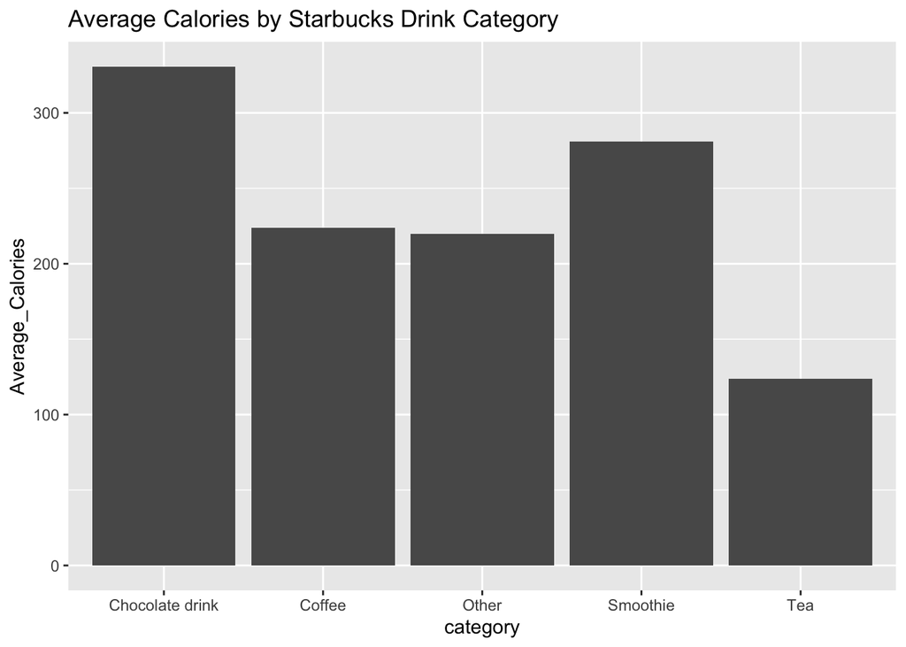

```r
# Create a visualization for average calories by category
ggplot(nutritional_summary, aes(x = category, y = Average_Calories)) +
  geom_bar(stat = "identity") +
  labs(title = "Average Calories by Starbucks Drink Category")
```

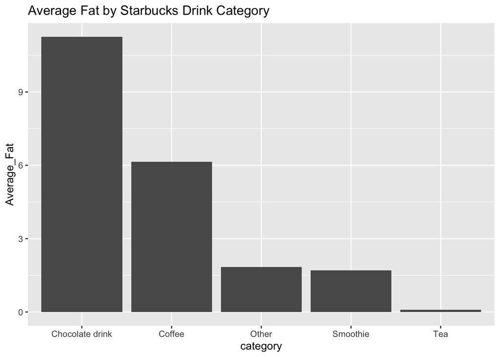

```r
# Create a visualization for average calories by category
ggplot(nutritional_summary, aes(x = category, y = Average_Fat)) +
  geom_bar(stat = "identity") +
  labs(title = "Average Fat by Starbucks Drink Category")
```

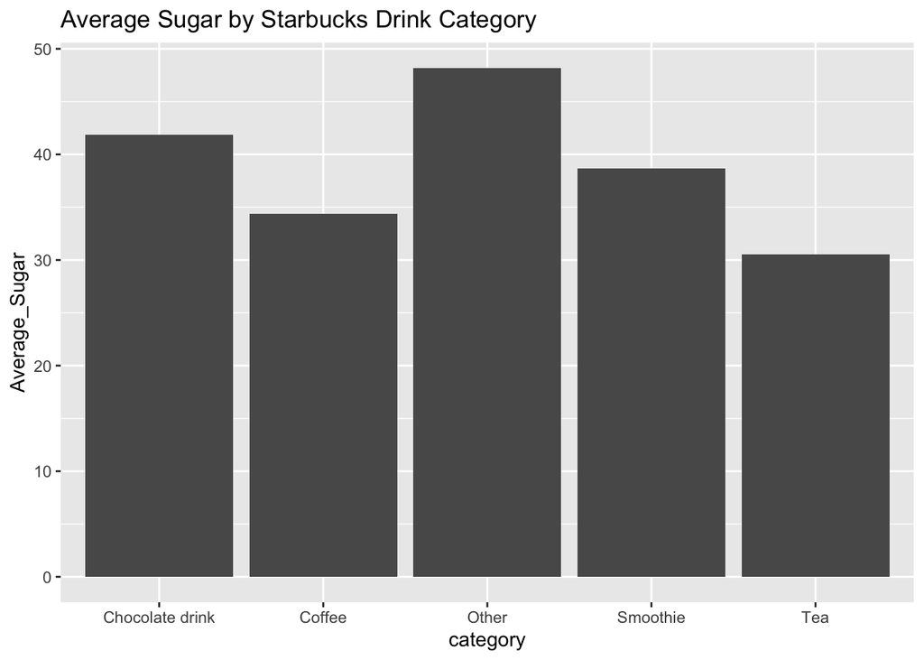

```r
# Create a visualization for average calories by category
ggplot(nutritional_summary, aes(x = category, y = Average_Sugar)) +
  geom_bar(stat = "identity") +
  labs(title = "Average Sugar by Starbucks Drink Category")
```

Histograms for Nutritional Content

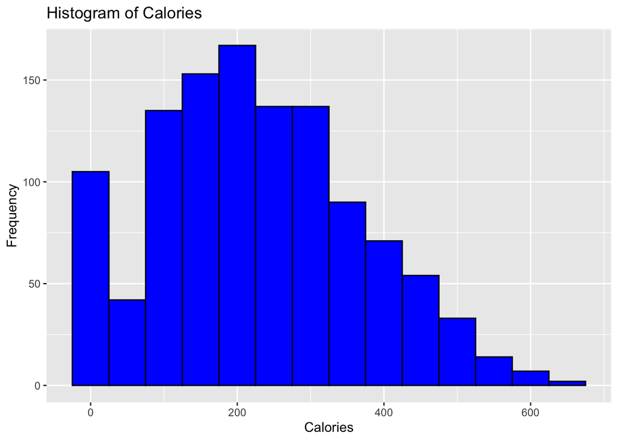

```r
library(ggplot2)

# Histogram for Calories
ggplot(starbucks2, aes(x = calories)) +
  geom_histogram(binwidth = 50, fill = 'blue', color = 'black') +
  labs(title = "Histogram of Calories", x = "Calories", y = "Frequency")
```

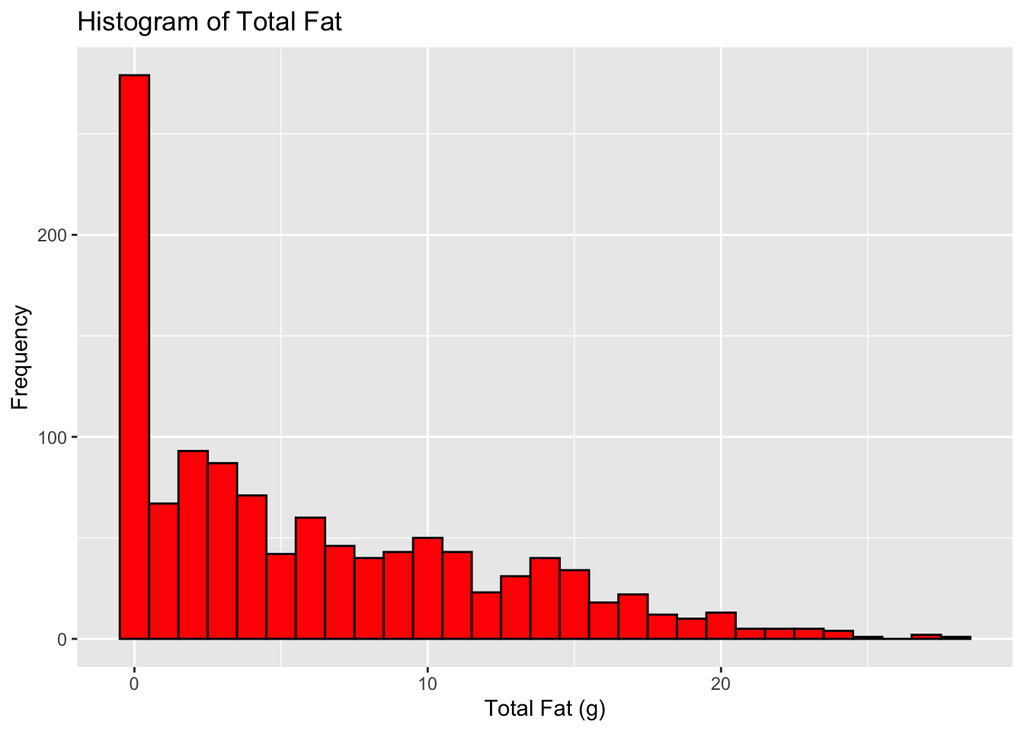

```r
# Histogram for Total Fat
ggplot(starbucks2, aes(x = total_fat_g)) +
  geom_histogram(binwidth = 1, fill = 'red', color = 'black') +
  labs(title = "Histogram of Total Fat", x = "Total Fat (g)", y = "Frequency")
```

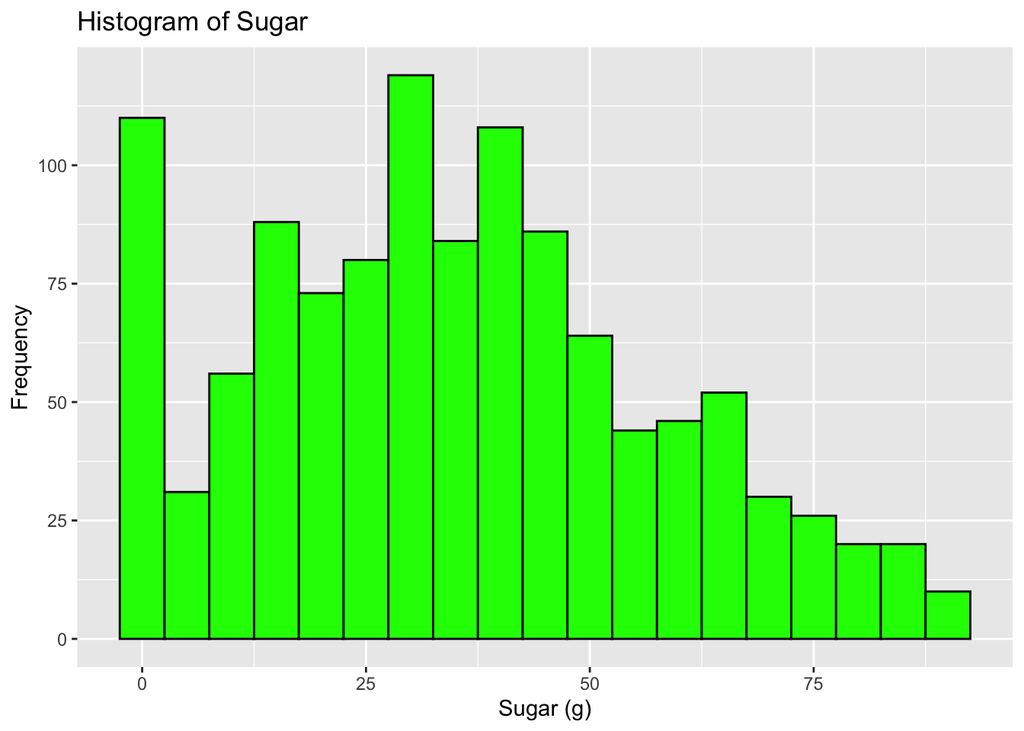

```r
# Histogram for Sugar
ggplot(starbucks2, aes(x = sugar_g)) +
  geom_histogram(binwidth = 5, fill = 'green', color = 'black') +
  labs(title = "Histogram of Sugar", x = "Sugar (g)", y = "Frequency")
```

Boxplots for Nutritional Content by Category

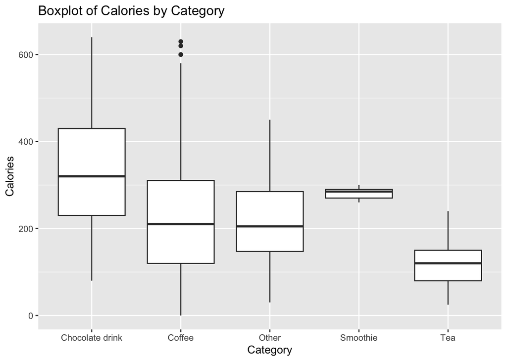

```r
# Boxplot for Calories by Category
ggplot(starbucks2, aes(x = category, y = calories)) +
  geom_boxplot() +
  labs(title = "Boxplot of Calories by Category", x = "Category", y = "Calories")
```

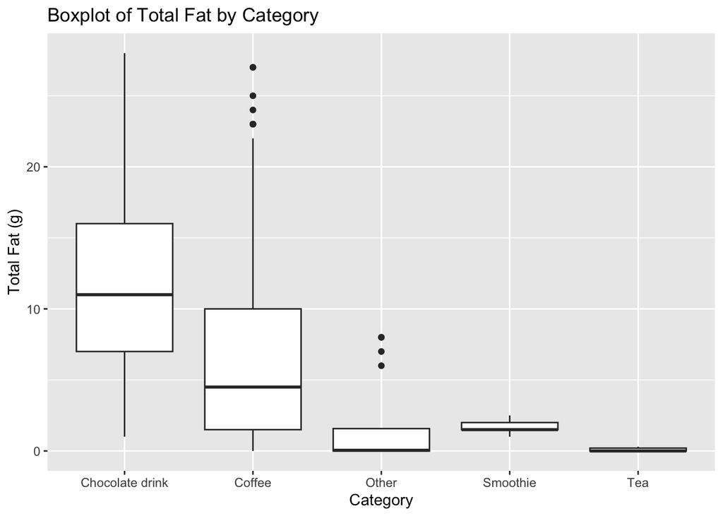

```r
# Boxplot for Total Fat by Category
ggplot(starbucks2, aes(x = category, y = total_fat_g)) +
  geom_boxplot() +
  labs(title = "Boxplot of Total Fat by Category", x = "Category", y = "Total Fat (g)")
```

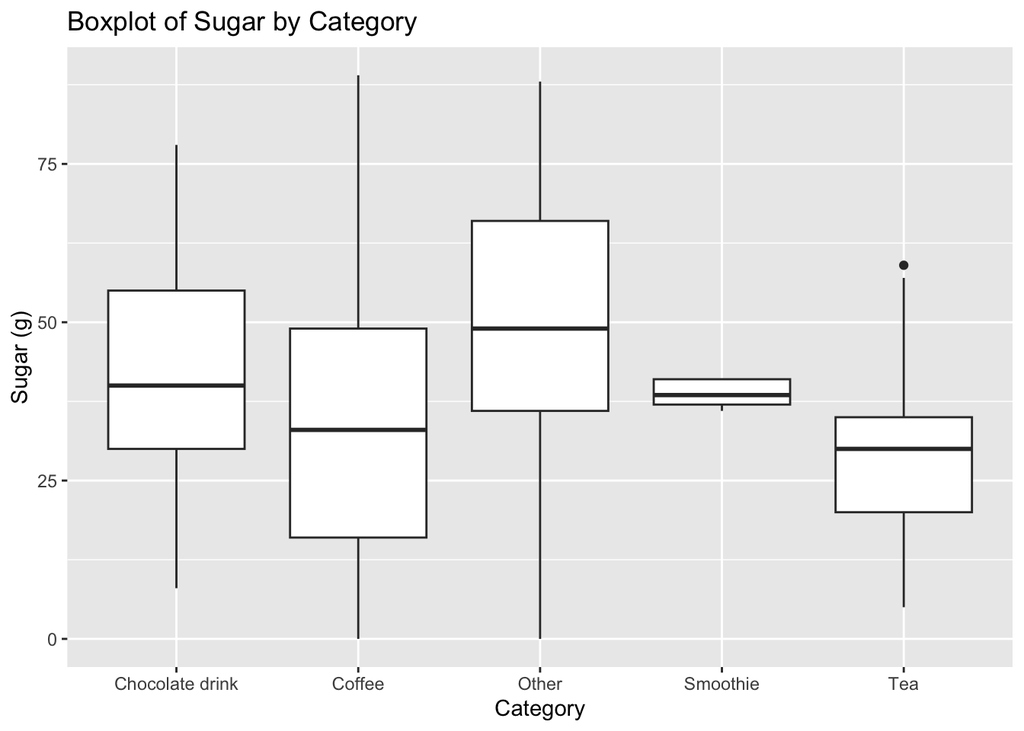

```r
# Boxplot for Sugar by Category
ggplot(starbucks2, aes(x = category, y = sugar_g)) +
  geom_boxplot() +
  labs(title = "Boxplot of Sugar by Category", x = "Category", y = "Sugar (g)")
```

Pairwise Relationships with Faceting (useful for multiple numeric variables)

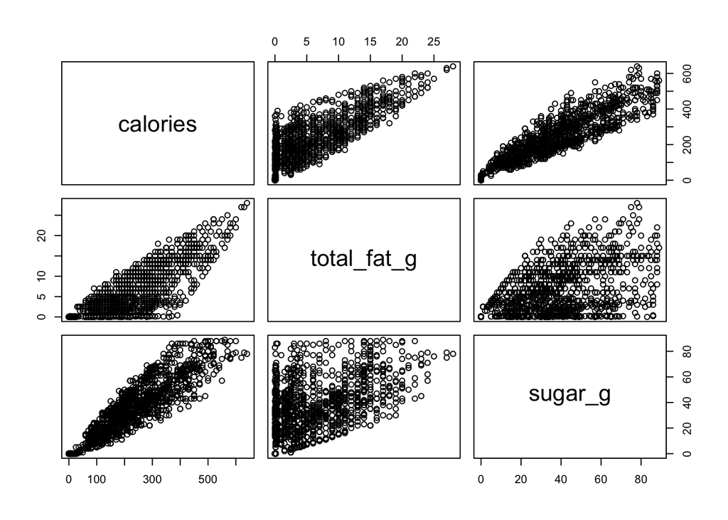

```r
# Pairwise scatter plots for nutritional content
pairs(starbucks[, c("calories", "total_fat_g", "sugar_g")])
```

The matrix of scatter plots shows the relationships between three variables: calories, total fat (in grams), and sugar (in grams). This type of visualization is often used in exploratory data analysis to quickly assess the pairwise relationships between multiple continuous variables.

1. Calories vs. Total Fat: There is a positive correlation, indicating that as the fat content increases, the calorie content also tends to increase. This is expected, as fat has a high caloric density.
2. Calories vs. Sugar: Similarly, there is a positive correlation, which means that higher sugar content in a beverage tends to be associated with higher calorie content. This is also expected since sugar is a carbohydrate that contributes to the total caloric intake.
3. Total Fat vs. Sugar: This plot shows a less clear relationship compared to the other two. While there seems to be some level of positive association, the relationship does not appear to be as strong or as linear as with calories. This suggests that the fat and sugar content in beverages can vary independently to some extent.

Correlation Matrix Heatmap (for numerical variables)

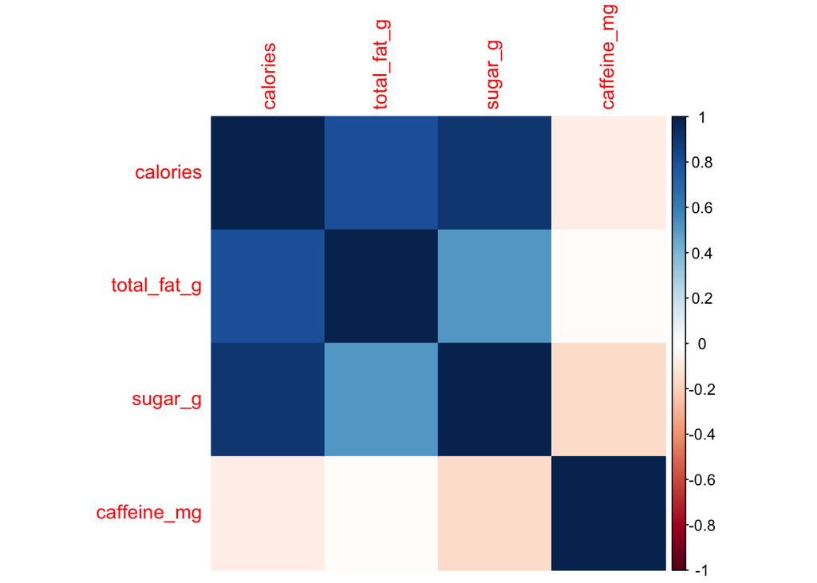

```r
library(corrplot)
# Calculate correlation matrix
cor_matrix <- cor(starbucks[, c("calories", "total_fat_g", "sugar_g", "caffeine_mg")])

# Correlation matrix heatmap
corrplot(cor_matrix, method = "color")
```

The correlation matrix heatmap visualizes the Pearson correlation coefficients between several variables, typically to show how strongly each pair of variables is related.

## Verifying that statistical tests are reliable and valid (e.g. residual diagnostics, assumption checks)

```r
# Perform ANOVA for Calories
anova_calories <- aov(calories ~ category, data = starbucks2)
summary(anova_calories)
```

```
##               Df   Sum Sq Mean Sq F value Pr(>F)
## category       4  1517584  379396   21.45 <2e-16 ***
## Residuals   1142 20202864   17691
## ---
## Signif. codes:  0 '***' 0.001 '**' 0.01 '*' 0.05 '.' 0.1 ' ' 1
```

```r
# Perform ANOVA for Fat
anova_fat <- aov(total_fat_g ~ category, data = starbucks2)
summary(anova_fat)
```

```
##               Df Sum Sq Mean Sq F value Pr(>F)
## category       4   4619  1154.7   36.45 <2e-16 ***
## Residuals   1142  36172    31.7
## ---
## Signif. codes:  0 '***' 0.001 '**' 0.01 '*' 0.05 '.' 0.1 ' ' 1
```

```r
# Perform ANOVA for Sugar
anova_sugar <- aov(sugar_g ~ category, data = starbucks2)
summary(anova_sugar)
```

```
##               Df Sum Sq Mean Sq F value  Pr(>F)
## category       4   8540  2135.0   4.281 0.00192 **
## Residuals   1142 569502   498.7
## ---
## Signif. codes:  0 '***' 0.001 '**' 0.01 '*' 0.05 '.' 0.1 ' ' 1
```

```r
# Check for normality of residuals
shapiro.test(residuals(anova_calories))
```

```
##
##  Shapiro-Wilk normality test
##
## data:  residuals(anova_calories)
## W = 0.98103, p-value = 4.249e-11
```

```r
shapiro.test(residuals(anova_fat))
```

```
##
##  Shapiro-Wilk normality test
##
## data:  residuals(anova_fat)
## W = 0.92003, p-value < 2.2e-16
```

```r
shapiro.test(residuals(anova_sugar))
```

```
##
##  Shapiro-Wilk normality test
##
## data:  residuals(anova_sugar)
## W = 0.97211, p-value = 4.619e-14
```

None of the residuals from the ANOVA models for calories, fat, or sugar are normally distributed according to the Shapiro-Wilk test. This could have implications for the validity of any parametric tests (like ANOVA) that assume normality of residuals. Nonparametric methods or data transformation might be necessary for further analysis.

```r
# Check for homogeneity of variance
bartlett.test(calories ~ category, data = starbucks2)
```

```
##
##  Bartlett test of homogeneity of variances
##
## data:  calories by category
## Bartlett's K-squared = 80.885, df = 4, p-value < 2.2e-16
```

```r
bartlett.test(total_fat_g ~ category, data = starbucks2)
```

```
##
##  Bartlett test of homogeneity of variances
##
## data:  total_fat_g by category
## Bartlett's K-squared = 361.53, df = 4, p-value < 2.2e-16
```

```r
bartlett.test(sugar_g ~ category, data = starbucks2)
```

```
##
##  Bartlett test of homogeneity of variances
##
## data:  sugar_g by category
## Bartlett's K-squared = 63.628, df = 4, p-value = 5.005e-13
```

The Bartlett test results indicate that the assumption of homogeneity of variances is violated for the variables calories, total fat, and sugar across the different categories. This is an important assumption for ANOVA, as the test assumes that variances are equal across groups or treatment levels.

When the assumption of homogeneity of variances is violated we can proceed with Welch’s ANOVA. Welch’s ANOVA is a version of ANOVA that does not assume equal variances and can be a good alternative when the Bartlett test indicates significant differences in variances.

```r
# Welch's ANOVA for Calories
welch_anova_calories <- oneway.test(calories ~ category, data = starbucks2)

# Welch's ANOVA for Total Fat
welch_anova_fat <- oneway.test(total_fat_g ~ category, data = starbucks2)

# Welch's ANOVA for Sugar
welch_anova_sugar <- oneway.test(sugar_g ~ category, data = starbucks2)

# Output the results
welch_anova_calories
```

```
##
##  One-way analysis of means (not assuming equal variances)
##
## data:  calories and category
## F = 89.069, num df = 4.000, denom df = 58.554, p-value < 2.2e-16
```

```r
welch_anova_fat
```

```
##
##  One-way analysis of means (not assuming equal variances)
##
## data:  total_fat_g and category
## F = 346.69, num df = 4.000, denom df = 42.545, p-value < 2.2e-16
```

```r
welch_anova_sugar
```

```
##
##  One-way analysis of means (not assuming equal variances)
##
## data:  sugar_g and category
## F = 9.8116, num df = 4.000, denom df = 62.201, p-value = 3.22e-06
```

The Welch ANOVA results:

1. Calories: The F-statistic is 89.069 with numerator degrees of freedom (df) of 4 and denominator df of 58.554. The p-value is less than 2.2e-16, which is extremely small.

Interpretation: There is a statistically significant difference in the mean calorie content across the different categories of Starbucks beverages.

2. Total Fat: The F-statistic is 346.69 with numerator df of 4 and denominator df of 42.545. The p-value is less than 2.2e-16, which is extremely small.

Interpretation: There is a statistically significant difference in the mean total fat content across the different categories of Starbucks beverages.

3. Sugar: The F-statistic is 9.8116 with numerator df of 4 and denominator df of 62.201. The p-value is 3.22e-06, which is also very small.

Interpretation: There is a statistically significant difference in the mean sugar content across the different categories of Starbucks beverages.

The results for all three nutritional content analyses (calories, fat, and sugar) suggest that the drink categories are significantly different in terms of their nutritional makeup. The next step is post-hoc analysis to determine which specific categories differ from each other.

Non-parametric Tests: Since the data is also not normally distributed, a non-parametric equivalent to ANOVA, like the Kruskal-Wallis test would be the best approach.

```r
# Kruskal-Wallis test for Calories
kruskal_test_calories <- kruskal.test(calories ~ category, data = starbucks2)

# Kruskal-Wallis test for Total Fat
kruskal_test_fat <- kruskal.test(total_fat_g ~ category, data = starbucks2)

# Kruskal-Wallis test for Sugar
kruskal_test_sugar <- kruskal.test(sugar_g ~ category, data = starbucks2)

# Output the results
kruskal_test_calories
```

```
##
##  Kruskal-Wallis rank sum test
##
## data:  calories by category
## Kruskal-Wallis chi-squared = 87.835, df = 4, p-value < 2.2e-16
```

```r
kruskal_test_fat
```

```
##
##  Kruskal-Wallis rank sum test
##
## data:  total_fat_g by category
## Kruskal-Wallis chi-squared = 169.73, df = 4, p-value < 2.2e-16
```

```r
kruskal_test_sugar
```

```
##
##  Kruskal-Wallis rank sum test
##
## data:  sugar_g by category
## Kruskal-Wallis chi-squared = 19.343, df = 4, p-value = 0.000673
```

Interpretation for non parametric test

The Kruskal-Wallis test is a non-parametric method used to determine if there are statistically significant differences between the medians of three or more independent groups. It is an alternative to ANOVA when the assumptions are violated.

The results of the Kruskal-Wallis tests:

1. Calories: The Kruskal-Wallis chi-squared statistic is 87.835 with 4 degrees of freedom and a p-value < 2.2e-16. This extremely low p-value suggests that there is a statistically significant difference in the median calories among the different categories of Starbucks beverages.
2. Total Fat: The Kruskal-Wallis chi-squared statistic is 169.73 with 4 degrees of freedom and a p-value < 2.2e-16. Similar to calories, this result indicates a statistically significant difference in the median total fat grams across the beverage categories.
3. Sugar: The Kruskal-Wallis chi-squared statistic is 19.343 with 4 degrees of freedom and a p-value of 0.000673. The median sugar content also significantly varies across the categories.

Based on the very low p-values in all three tests we reject the null hypothesis for each nutritional component, which states that there are no differences in medians across groups.

Given these results, further investigation with post-hoc tests could be done to find exactly which categories differ from each other.

One common post hoc test for the Kruskal-Wallis is the Dunn test.

```r
library(dunn.test)

# Perform Dunn test for Calories
dunn_test_calories <- dunn.test(starbucks2$calories, starbucks2$category, method="bonferroni")
```

```
##   Kruskal-Wallis rank sum test
##
## data: x and group
## Kruskal-Wallis chi-squared = 87.8351, df = 4, p-value = 0
##
##
##                            Comparison of x by group
##                                  (Bonferroni)
## Col Mean-|
## Row Mean |   Chocolat     Coffee      Other   Smoothie
## ---------+--------------------------------------------
##   Coffee |   6.889113
##          |    0.0000*
##    Other |   2.866311   0.062463
##          |    0.0208*     1.0000
## Smoothie |   0.507970  -1.866291  -1.510520
##          |     1.0000     0.3100     0.6546
##      Tea |   8.935500   5.649427   2.817236   4.092518
##          |    0.0000*    0.0000*    0.0242*    0.0002*
##
## alpha = 0.05
## Reject Ho if p <= alpha/2
```

```r
dunn_test_calories
```

```
## $chi2
## [1] 87.8351
##
## $Z
##  [1]  6.88911397  2.86631196  0.06246376  0.50797078 -1.86629187 -1.51052012
##  [7]  8.93550051  5.64942780  2.81723693  4.09251873
##
## $P
##  [1] 2.807047e-12 2.076424e-03 4.750968e-01 3.057369e-01 3.100027e-02
##  [6] 6.545538e-02 2.026696e-19 8.049139e-09 2.421939e-03 2.133564e-05
##
## $P.adjusted
##  [1] 2.807047e-11 2.076424e-02 1.000000e+00 1.000000e+00 3.100027e-01
##  [6] 6.545538e-01 2.026696e-18 8.049139e-08 2.421939e-02 2.133564e-04
##
## $comparisons
##  [1] "Chocolate drink - Coffee"   "Chocolate drink - Other"
##  [3] "Coffee - Other"             "Chocolate drink - Smoothie"
##  [5] "Coffee - Smoothie"          "Other - Smoothie"
##  [7] "Chocolate drink - Tea"      "Coffee - Tea"
##  [9] "Other - Tea"                "Smoothie - Tea"
```

```r
# Perform Dunn test for Total Fat
dunn_test_fat <- dunn.test(starbucks2$total_fat_g, starbucks2$category, method="bonferroni")
```

```
##   Kruskal-Wallis rank sum test
##
## data: x and group
## Kruskal-Wallis chi-squared = 169.7309, df = 4, p-value = 0
##
##
##                            Comparison of x by group
##                                  (Bonferroni)
## Col Mean-|
## Row Mean |   Chocolat     Coffee      Other   Smoothie
## ---------+--------------------------------------------
##   Coffee |   7.187076
##          |    0.0000*
##    Other |   6.586292   3.939654
##          |    0.0000*    0.0004*
## Smoothie |   4.514888   2.234635  -0.701187
##          |    0.0000*     0.1272     1.0000
##      Tea |   12.21350   9.407832   1.334207   1.921697
##          |    0.0000*    0.0000*     0.9107     0.2732
##
## alpha = 0.05
## Reject Ho if p <= alpha/2
```

```r
dunn_test_fat
```

```
## $chi2
## [1] 169.7309
##
## $Z
##  [1]  7.1870765  6.5862925  3.9396545  4.5148885  2.2346353 -0.7011878
##  [7] 12.2135023  9.4078329  1.3342077  1.9216973
##
## $P
##  [1] 3.309667e-13 2.254725e-11 4.079952e-05 3.167504e-06 1.272065e-02
##  [6] 2.415929e-01 1.316529e-34 2.532356e-21 9.106789e-02 2.732193e-02
##
## $P.adjusted
##  [1] 3.309667e-12 2.254725e-10 4.079952e-04 3.167504e-05 1.272065e-01
##  [6] 1.000000e+00 1.316529e-33 2.532356e-20 9.106789e-01 2.732193e-01
##
## $comparisons
##  [1] "Chocolate drink - Coffee"   "Chocolate drink - Other"
##  [3] "Coffee - Other"             "Chocolate drink - Smoothie"
##  [5] "Coffee - Smoothie"          "Other - Smoothie"
##  [7] "Chocolate drink - Tea"      "Coffee - Tea"
##  [9] "Other - Tea"                "Smoothie - Tea"
```

```r
# Perform Dunn test for Sugar
dunn_test_sugar <- dunn.test(starbucks2$sugar_g, starbucks2$category, method="bonferroni")
```

```
##   Kruskal-Wallis rank sum test
##
## data: x and group
## Kruskal-Wallis chi-squared = 19.3425, df = 4, p-value = 0
##
##
##                            Comparison of x by group
##                                  (Bonferroni)
## Col Mean-|
## Row Mean |   Chocolat     Coffee      Other   Smoothie
## ---------+--------------------------------------------
##   Coffee |   3.372067
##          |    0.0037*
##    Other |  -0.868108  -2.416406
##          |     1.0000     0.0784
## Smoothie |   0.139760  -1.027762   0.700404
##          |     1.0000     1.0000     1.0000
##      Tea |   2.989352   1.082845   2.665503   1.398151
##          |    0.0140*     1.0000     0.0384     0.8103
##
## alpha = 0.05
## Reject Ho if p <= alpha/2
```

```r
dunn_test_sugar
```

```
## $chi2
## [1] 19.34252
##
## $Z
##  [1]  3.3720673 -0.8681082 -2.4164067  0.1397600 -1.0277628  0.7004046
##  [7]  2.9893527  1.0828456  2.6655032  1.3981516
##
## $P
##  [1] 0.0003730311 0.1926675431 0.0078372713 0.4444247899 0.1520307052
##  [6] 0.2418373272 0.0013978461 0.1394384900 0.0038436601 0.0810337665
##
## $P.adjusted
##  [1] 0.003730311 1.000000000 0.078372713 1.000000000 1.000000000 1.000000000
##  [7] 0.013978461 1.000000000 0.038436601 0.810337665
##
## $comparisons
##  [1] "Chocolate drink - Coffee"   "Chocolate drink - Other"
##  [3] "Coffee - Other"             "Chocolate drink - Smoothie"
##  [5] "Coffee - Smoothie"          "Other - Smoothie"
##  [7] "Chocolate drink - Tea"      "Coffee - Tea"
##  [9] "Other - Tea"                "Smoothie - Tea"
```

Based on the Dunn test results of the post hoc analysis for the sugar content in different Starbucks beverage categories:

Coffee vs. Chocolate drinks: There is a statistically significant difference in sugar content between Coffee and Chocolate categories, with Coffee likely having less sugar than Chocolate, given the positive z-value (3.372067) and a very small adjusted p-value (p < 0.05 after Bonferroni adjustment).

Chocolat vs. Tea: The Chocolat drink category and Tea also show a statistically significant difference, with Chocolat drinks likely having more sugar, as suggested by the positive z-value (2.989352) and a small adjusted p-value (p < 0.05 after Bonferroni adjustment).

The other pairwise comparisons between categories did not show statistically significant differences in sugar content after adjusting for multiple comparisons. ########################################################

Based on the Dunn test results of the post hoc analysis for the total fat content in different Starbucks beverage categories:

Coffee vs. Chocolate drinks: There is a statistically significant difference in total fat content between Coffee and Chocolate categories, with Coffee likely having less total fat than Chocolate, given the positive z-value (7.187) and a very small adjusted p-value.

Smoothie vs. Chocolat: The smoothie category and Chocolate drinks also show a statistically significant difference with positive z-value (4.514888 ) and a small adjusted p-value.

Tea vs. Chocolat: The tea category and Chocolate drinks also show a statistically significant difference with positive z-value (12.21350 ) and a small adjusted p-value.

Coffee vs. Chocolate drinks: There is a statistically significant difference in calorie content between Coffee and Chocolate categories, with Coffee likely having less total fat than Chocolate, given the positive z-value (6.889113) and a very small adjusted p-value.

Chocolat vs. Other: The Chocolat drink category and other drinks also show a statistically significant difference with positive z-value (2.866311 ) and a small adjusted p-value.

Chocolat vs. Tea: The Chocolat drink category and tea drinks also show a statistically significant difference with positive z-value (8.935500) and a small adjusted p-value.